# Econometrics: Endogeneity and Instrumental Variables

### Some properties of binary choice models

Suppose that $y_i$ is a binary dependent variable and that $y_i$ can only take the values 0 and 1 for $i = 1,...,n$. Consider the linear regression model. Assume $E(\epsilon_i)=0$

$$y_i = \beta_1 + \beta_2 \cdot x_i + \epsilon_i$$

- How can we express the expected value of $y_i$ expressed in terms of the parameters and $x_i$?

$$E(y_i) = E(\beta_1 + \beta_2 \cdot x_i + \epsilon_i) = \beta_1 + \beta_2 \cdot x_i$$

- With this result we can show that the expected value of $y_i$ equals the probability that $y_i$ equals 1. $E(y_i)=Pr(y=1)$

$$E(y_i) = 1 \cdot Pr(y=1) + 0 \cdot Pr(y=0) = Pr(y=1)$$
- What is the probability that $y_i$ equals 0 expressed in terms of $x_i$ and the $\beta$ parameters?

$$Pr(y=0) = 1 - Pr(y=1) = 1 - \beta_1 + \beta_2 \cdot x_i$$

- Since $y_i$ can only take two values, there are two possible values for the error term given the value of $x_i$ and the parameters $\beta$. Give these two values and also provide the probability that these two values occur.

$$\epsilon_i =
\begin{cases}
1 - \beta_1 + \beta_2 \cdot x_i &\quad\text{occurs with Prob : } \beta_1 + \beta_2 \cdot x_i \\
0 - \beta_1 + \beta_2 \cdot x_i &\quad\text{occurs with Prob : } 1- \beta_1 + \beta_2 \cdot x_i
\end{cases}$$

- What is the variance of $\epsilon_i$ expressed in terms of $x_i$ and the $\beta$ parameters? Are the errors homoscedastic?

$$Var(\epsilon_i) = E[(\epsilon_i-E(\epsilon_i))^2] = E[\epsilon_i^2]$$
$$Var(\epsilon_i) = (1- \beta_1 + \beta_2 \cdot x_i)^2 \cdot Pr(y_i=1) + (- \beta_1 + \beta_2 \cdot x_i)^2 \cdot Pr(y_i=0)$$
$$Var(\epsilon_i) = (1- \beta_1 + \beta_2 \cdot x_i)^2 \cdot (\beta_1 + \beta_2 \cdot x_i) + (- \beta_1 + \beta_2 \cdot x_i)^2 \cdot (1- \beta_1 + \beta_2 \cdot x_i )$$
$$Var(\epsilon_i) = (1- \beta_1 + \beta_2 \cdot x_i) (\beta_1 + \beta_2 \cdot x_i) (1 - \beta_1 + \beta_2 \cdot x_i + \beta_1 + \beta_2 \cdot x_i ) = (1- \beta_1 + \beta_2 \cdot x_i) (\beta_1 + \beta_2 \cdot x_i)$$

The variance of the errors are different for each observation, therefore the errors are [heteroscedastic](https://diego-eco.github.io/files/econometrics_simple_multiple.html#evaluation_of_parameters).

## Specify binary choice

We will call the dependent variable $y_i$ and it can take only two values. We note these values by zero and one. The value one may, for example, correspond to yes and the value zero to no. Instead of assuming a normal distribution for $y_i$, as is done in previous sections, we now assume that y follows a Bernoulli distribution with parameter $\pi$.

The Bernoulli distribution implies that $y_i$ has two possible outcomes denoted by 0 and 1 the probability that the outcome is one equals $\pi$.

$$y_i \sim Bernoulli(\pi)$$
$$\text{Such that } \space \pi = Pr[y_i=1] \space \text{ with } 0 < \pi < 1$$
$$\text{And hence } \space Pr[y_i=0] = 1 - \pi$$

The probability that $y_i$ is zero is then $1 - \pi$, as probabilities have to sum up to one. Note that **instead of modeling the value of y itself, we now model the probability that y is 1**. For many applications, it is very unlikely that the probability that $y_i=1$ is the same for all observations. Therefore we allow the probability $\pi$ to differ across individuals, or time periods in case we have observations over time. **Hence we consider pi subscript i.**

$$\text{Individual specific probabilities : } \space Pr[y_i=1] = \pi_i$$

### Logistic function

To explain differences in probabilities across individuals, we can relate the probabilities $\pi_i$ to one or more explanatory variables. Given the fact that probabilities have to be between 0 and 1, we cannot just take any function for this relationship. Although there are several choices possible, in practice, the **[logistic function](https://en.wikipedia.org/wiki/Logistic_function)** is most frequently chosen. A logistic function or logistic curve is a common S-shaped curve (sigmoid curve) with equation:

$$f(x)=\frac{L}{1+e^{-k(x-x_0)}}$$
Where $x_0$ the $x$ value of the sigmoid’s midpoint, $L$ is the curve’s maximum value and $k$ the logistic growth rate or steepness of the curve.

To simplify the discussion, we first consider a situation with only one explanatory variable x_i. In our application, the function looks like:

$$Pr[y_i=1] = \frac{exp(\beta_1+\beta_2x_i)}{1+exp(\beta_1+\beta_2x_i)}$$
$$Pr[y_i=0] =1- \frac{exp(\beta_1+\beta_2x_i)}{1+exp(\beta_1+\beta_2x_i)} = \frac{1}{1+exp(\beta_1+\beta_2x_i)}$$

As you can see, the logistic function implies that the probability $\pi_i$ is a ratio. The numerator is the exponent of a linear combination of a constant and an explanatory variable $x_i$. The denominator is 1 plus the same exponent term. The $\beta_1$ parameter is called the intercept parameter, and the $\beta_2$ parameter describes the effect of $x_i$ on $y$.

This graph shows the plot of the probability $y = 1$ as a function of the explanatory variable $x_i$. We consider the case where the Intercept parameter $\beta_1=0$, and the parameter $\beta_2=1$.

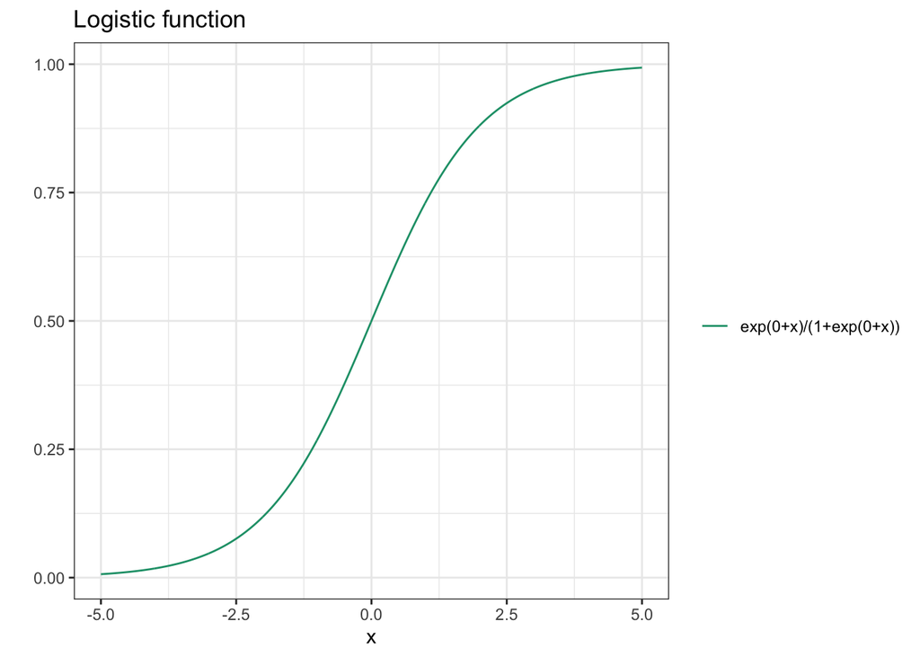

```r
x <- seq(-5, 5, 0.01)
y_1 <- (exp(0+x))/(1+exp(0+x))
y_2 <- (exp(0+3*x))/(1+exp(0+3*x))
y_3 <- (exp(0-x))/(1+exp(0-x))
y_4 <- (exp(2+x))/(1+exp(2+x))
y_5 <- (exp(-2+x))/(1+exp(-2+x))
sample <- tibble(x,y_1,y_2,y_3,y_4,y_5)
plot1 <- ggplot(data=sample, aes(x=x)) +
  geom_line(aes(y=y_1, col = "exp(0+x)/(1+exp(0+x))")) +
  #geom_line(aes(y=y_2, col = "exp(0+3x)/(1+exp(0+3x))")) +
  #geom_line(aes(y=y_3, col = "exp(0-x)/(1+exp(0-x))")) +
  #geom_line(aes(y=y_4, col = "exp(2+x)/(1+exp(2+x))")) +
  #geom_line(aes(y=y_5, col = "exp(-2+x)/(1+exp(-2+x))")) +
  labs(x = "x", y = "",
  title = "Logistic function") +
  theme_bw() +
  scale_color_brewer(name= NULL, palette = "Dark2")
plot1
```

You can clearly see that the probability is bounded between 0 and 1. The probability that $Pr[y = 1]=1/2$ when $x_i=0$. In general, the probability increases when $x$ increases. The increase in probability is, however, not linear like in a linear regression model. For small values of x, the probability is really close to zero, and for large x the probability is nearly one.

To illustrate the role of the beta_2 parameter, we now change the size of this parameter. The new line shows the probability that $y = 1$ in case $\beta_2$ is three times as large. You can clearly see that the logistic function now is steeper:

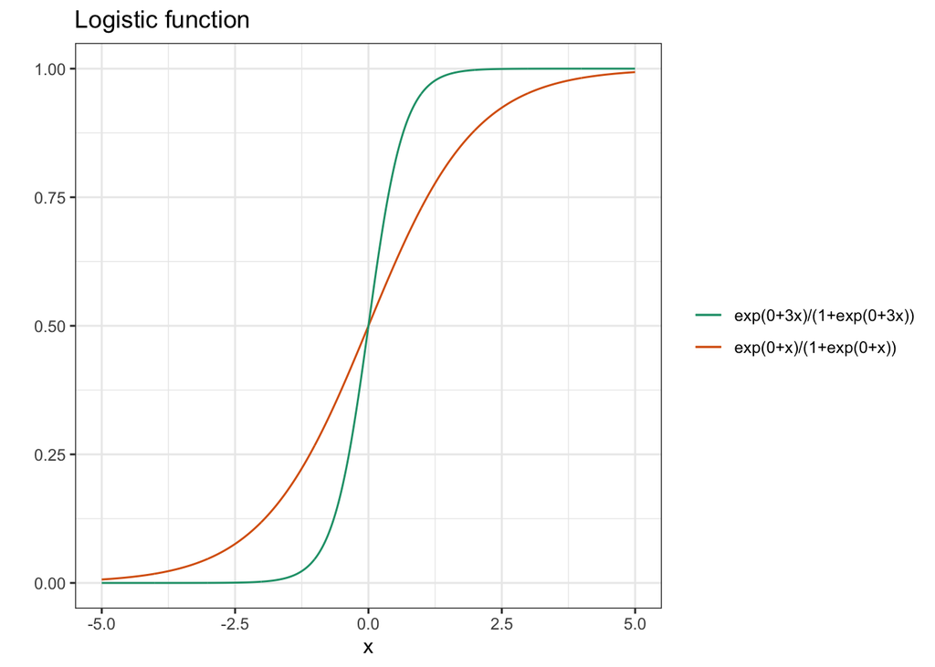

The interval where the probability is not close to the boundaries 0 and 1, is now smaller. Hence, for larger $\beta_2$ values, there is less uncertainty in whether y equals 0 or 1 given the value of $x$.

Now we’ve made the $\beta_2$ parameter negative. The new line shows a logit probability in case $\beta_2 = -1$. You can see that the logit probability is now a decreasing function of x. In fact, the probability plot is the mirror image of the original plot if you place a mirror vertically at x equal to 0.

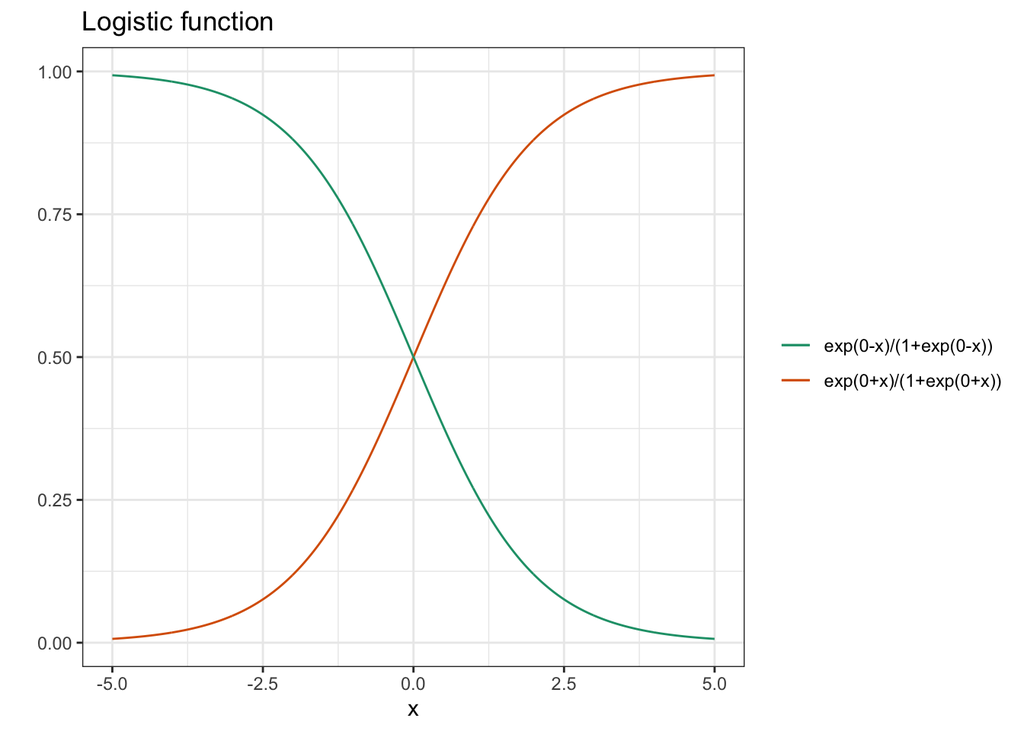

Let us now change the value of the intercept parameter $\beta_1$. The new line shows the logit probability where $\beta_1=2$ instead of 0. You can see that the shape of the logit function stays the same, but that the location has changed. The graph has moved two units of x to the left. The logit probability is now $1/2$ at $x=-2$, while in the original case, this happens at x equals 0. If we set $\beta_1=-2$the graph moves two units to the right and the shape of the curve stays the same.

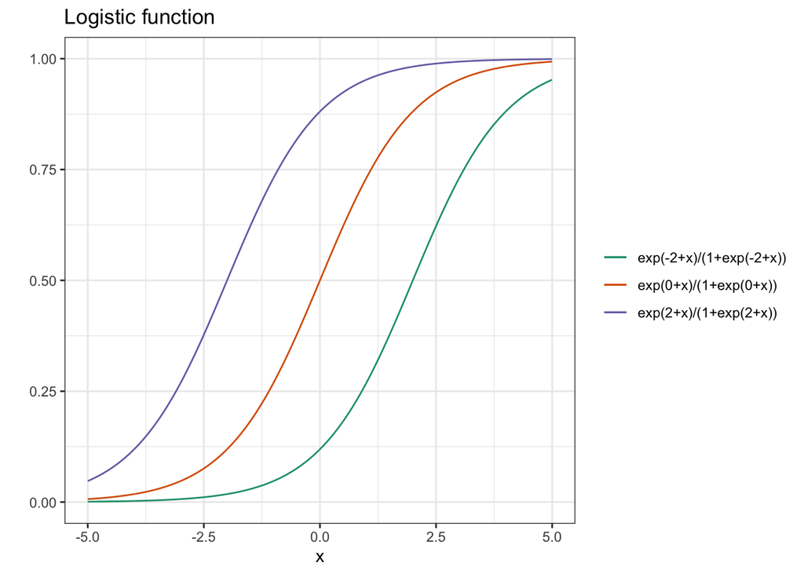

As you have already seen in the previous graphs, the probability that $y = 1$ is a non-linear function of the explanatory variable $x$. This makes parameter interpretation a bit more difficult than in a linear regression.

$$\begin{split}
\text{Logit Model : } & \\
& Pr[y_i=1] = \frac{exp(\beta_1+\beta_2x_i)}{1+exp(\beta_1+\beta_2x_i)} \\
& Pr[y_i=0] = \frac{1}{1+exp(\beta_1+\beta_2x_i)}
\end{split}$$

### Odds ratio

The easiest way to interpret the parameters of a logit model is to consider the **odds ratio**. That is, the ratio of the probability that $y = 1$ and the probability that $y = 0$. In the odds ratio the denominator of the logit probability cancels out, which results in a simple expression.

$$\begin{split}
\text{Odds ratio : } & \\
& \frac{Pr[y_i=1]}{Pr[y_i=0]} = exp(\beta_1+\beta_2x_i)
\end{split}$$

In fact, it is even easier to consider the log odds ratio, as this is linear in x. It is easy to see that a positive $\beta_2$ implies that increase in x leads to an increase in the log odds ratio. This also implies an increase in the odds ratio itself. The opposite holds for negative $\beta_2$. An increase in x leads to a decrease in the log odds ratio and hence a decrease in the probability that $y = 1$.

$$\begin{split}
\text{Log Odds ratio : } & \\
& log \left ( \frac{Pr[y_i=1]}{Pr[y_i=0]} \right ) = \beta_1+\beta_2x_i
\end{split}$$

The odds ratio provides insight into the direction, plus or minus, of the effect of changes in the x variable, but not in the size of the effect. To compute the size of the effect, we consider the marginal effect of a change in x on the probability.

### Marginal and average effect

It can be shown that for the logit model, the first derivative of the probability that $y = 1$, with respect to $x$, can be written as a product of probability that $y = 1$ times the probability that $y = 0$ times $\beta_2$. Here we use the chain rule to derive the result as shown end of the section, no we just focus on the several conclusions that can be drawn from this result. First of all, as probabilities are always positive, the sign of $\beta_2$ determines direction of the marginal effect.

$$\begin{split}
\text{Marginal effect : } & \\
& \frac{d Pr[y_i=1]}{dx_i} = Pr[y_i=1] \cdot Pr[y_i=0]\beta_2
\end{split}$$

This result was already clear from the odds ratio. A positive $\beta_2$ implies that an increase in x leads to an increase in the probability that $y = 1$. Secondly, when the probability that $y = 1$ is almost zero, the effect of a change in x is also almost zero. The same holds when the probability that $y = 0$ is almost zero.

Remember from the graphs of the logit function shown before that this happens for very large and very small values of x. Hence, a change in x has then almost no effect on the outcome of y, and the logit functions are flat for very large and small values of x. Know that this feature of the logit model is not present in a linear regression.

The value of the marginal effect also depends on the probability and hence on the value of x. This means that one cannot express the marginal effect in a single number. Computer packages often report the **average marginal effect in the sample**. You can obtain this quantity by computing the marginal effect for every value of $x_i$ in your sample and by taking the sample average.

$$\begin{split}
\text{Average marginal effect : } & \\
& \frac{1}{n}\sum^n_{i=1}\frac{d Pr[y_i=1]}{dx_i} = \left ( \frac{1}{n}\sum^n_{i=1}Pr[y_i=1] \cdot Pr[y_i=0] \right )\beta_2
\end{split}$$

### Multiple variables

So far, we have only considered logit models with only one explanatory variable. The logit model can easily be extended with more explanatory variables. Here you see a logit model with $k-1$ explanatory variables, which are denoted by $X_{j,i}$.

$$\begin{split}
\text{Logit with } x_{2i},x_{3i},...,x_{ki} & \\
& Pr[y_i=1] = \frac{exp(\beta_1+ \sum^k_{j=2}\beta_j x_{ji})}{1+exp(\beta_1+ \sum^k_{j=2}\beta_j x_{ji})}
\end{split}$$

The exponent term now contains a linear combination of the intercept and the $k-1$ explanatory variables and k beta parameters. The log odds ratio and marginal effect are similar as before. In fact, analyzing the effect of a change in one of the $x_{j,i}$ variables can be done the same way as in the single explanatory variable case, if we keep the value of all other $x$ variables fixed.

$$\begin{split}
\text{Log Odds ratio : } & \\
& log \left ( \frac{Pr[y_i=1]}{Pr[y_i=0]} \right ) = \beta_1+ \sum^k_{j=2}\beta_j x_{ji}
\end{split}$$

$$\begin{split}
\text{Marginal effect : } & \\
& \frac{\partial Pr[y_i=1]}{\partial x_{ji}} = Pr[y_i=1] \cdot Pr[y_i=0]\beta_j \space \space \forall j=2,3,...k
\end{split}$$

The corresponding $\beta_j$ parameter determines direction and the relative size of the effect of a change in $x_{j,i}$. Note that the values of the marginal effect now also depend on the values of the other x variables through the probabilities.

### Notes on the logit distribution

Suppose that an individual has two choices, denoted by 0 and 1. Let $u_i$ be an unobserved random variable that measures the difference in attractiveness (utility) between the choices 1 and 0. The attractiveness $u_i$ is a linear function of explanatory variables $x_{ji}$ with parameters $\beta_j$ and an error term, that is:

$$u_i= \beta_1+ \sum^k_{j=2}\beta_j x_{ji} + \eta_i$$

Where $\eta_i$ are IID random terms. Assume that individual $i$ chooses 1 when $u_i>0$ and chooses 0 when $u_i<0$. In other words, individual $i$ chooses the most attractive alternative. By translating this into choice probability we can derive the probability that $y_i = 1$ as follows:

$$Pr[y_i=1] = Pr[u_i>0] = Pr[\beta_1+ \sum^k_{j=2}\beta_j x_{ji} + \eta_i \geq 0 ] = Pr[\eta_i \geq 0 - \beta_1 - \sum^k_{j=2}\beta_j x_{ji}]$$
$$Pr[y_i=1] = Pr[-\eta_i \leq \beta_1 + \sum^k_{j=2}\beta_j x_{ji}]$$

- Assume that the distribution of $\eta_i$ is symmetric around 0 and hence $\eta_i$ has the same distribution as $-\eta_i$.Furthermore, assume that $\eta_i$ has a standard logistic distribution with cumulative distribution function (CDF):

$$F(\eta_i)=\frac{exp(\eta_i)}{1+exp(\eta_i)}$$
Under this condition, the $Pr[y_i=1]$ is given by replacing $-\eta_i$ by $\eta_i$ in the CDF.

$$Pr[y_i=1]= Pr[-\eta_i \leq \beta_1 + \sum^k_{j=2}\beta_j x_{ji}] = \frac{exp(\beta_1 + \sum^k_{j=2}\beta_j x_{ji})}{1+exp(\beta_1 + \sum^k_{j=2}\beta_j x_{ji})}$$

- From the previous result we can show that

$$\frac{\frac{\partial Pr[y_i=1]}{\partial x_{ji}}}{\frac{\partial Pr[y_i=1]}{\partial x_{li}}} = \frac{Pr[y_i=1] \cdot Pr[y_i=0]\beta_j}{Pr[y_i=1] \cdot Pr[y_i=0]\beta_l} = \frac{\beta_j}{\beta_l}$$

This implies that the relative size of the $\beta$ parameters is the same as the relative size of the marginal effects. If the $\beta_j$ is twice the size as the $\beta_l$ parameter, also the marginal effects.

- Use the chain rule to show that $\frac{\partial Pr[y_i=1]}{\partial x_{ji}} = Pr[y_i=1] \cdot Pr[y_i=0]\beta_j$:

Recall that
$$\begin{split}
\text{Logit with } x_{2i},x_{3i},...,x_{ki} & \\
& Pr[y_i=1] = \frac{exp(\beta_1+ \sum^k_{j=2}\beta_j x_{ji})}{1+exp(\beta_1+ \sum^k_{j=2}\beta_j x_{ji})}
\end{split}$$

By expressing the denominator as an inverse exponent we can use the product rule:

$$\frac{\partial Pr[y_i=1]}{\partial x_{ji}} =
\frac{\partial \frac{exp(\beta_1+ \sum^k_{j=2}\beta_j x_{ji})}{1+exp(\beta_1+ \sum^k_{j=2}\beta_j x_{ji})}}{\partial x_{ji}}$$

$$=
\left [ 1+exp(\beta_1+ \sum^k_{j=2}\beta_j x_{ji}) \right] ^{-1} \frac{\partial exp(\beta_1+ \sum^k_{j=2}\beta_j x_{ji})}{\partial x_{ji}} + exp(\beta_1+ \sum^k_{j=2}\beta_j x_{ji}) \frac{\partial (1+exp(\beta_1+ \sum^k_{j=2}\beta_j x_{ji})^{-1}}{\partial x_{ji}}$$

Let’s solve by separate the two derviatives:

$$\frac{\partial exp(\beta_1+ \sum^k_{j=2}\beta_j x_{ji})}{\partial x_{ji}} = exp(\beta_1+ \sum^k_{j=2}\beta_j x_{ji})\beta_j$$

$$\frac{\partial (1+exp(\beta_1+ \sum^k_{j=2}\beta_j x_{ji})^{-1}}{\partial x_{ji}} =\frac{-1}{(1+exp(\beta_1+ \sum^k_{j=2}\beta_j x_{ji})^2} \frac{\partial exp(\beta_1+ \sum^k_{j=2}\beta_j x_{ji}}{\partial x_{ji}} = \frac{(-1)exp(\beta_1+ \sum^k_{j=2}\beta_j x_{ji})\beta_j}{(1+exp(\beta_1+ \sum^k_{j=2}\beta_j x_{ji})^2}$$

So we input these results in the original derivative:

$$\frac{\partial Pr[y_i=1]}{\partial x_{ji}} = \left [ 1+exp(\beta_1+ \sum^k_{j=2}\beta_j x_{ji}) \right] ^{-1} exp(\beta_1+ \sum^k_{j=2}\beta_j x_{ji})\beta_j + exp(\beta_1+ \sum^k_{j=2}\beta_j x_{ji}) \frac{(-1)exp(\beta_1+ \sum^k_{j=2}\beta_j x_{ji})\beta_j}{(1+exp(\beta_1+ \sum^k_{j=2}\beta_j x_{ji})^2}$$
Simplifying:

$$\frac{\partial Pr[y_i=1]}{\partial x_{ji}} =
\frac{exp(\beta_1 + \sum^k_{j=2}\beta_j x_{ji})\beta_j}{1+exp(\beta_1+ \sum^k_{j=2}\beta_j x_{ji})} -
\frac{exp(\beta_1+ \sum^k_{j=2}\beta_j x_{ji})exp(\beta_1+ \sum^k_{j=2}\beta_j x_{ji})\beta_j}{(1+exp(\beta_1+ \sum^k_{j=2}\beta_j x_{ji})^2}$$

We can rewrite this expression in terms of probabilities and the $\beta$ parameters as:

$$\frac{exp(\beta_1 + \sum^k_{j=2}\beta_j x_{ji})}{1+exp(\beta_1+ \sum^k_{j=2}\beta_j x_{ji})} \beta_j -
\frac{exp(\beta_1+ \sum^k_{j=2}\beta_j x_{ji})exp(\beta_1+ \sum^k_{j=2}\beta_j x_{ji})}{(1+exp(\beta_1+ \sum^k_{j=2}\beta_j x_{ji})^2} \beta_j = Pr[y_i=1]\beta_j-Pr[y_i=1]Pr[y_i=1]\beta_j$$
We factorize $\beta_j$ and replace $1-Pr[y_i=1] = Pr[y_i=0]$ by properties of probabilities.

$$\frac{\partial Pr[y_i=1]}{\partial x_{ji}} = Pr[y_i=1](1-Pr[y_i=1])\beta_j = Pr[y_i=1]Pr[y_i=0]\beta_j$$

$$\frac{\partial Pr[y_i=1]}{\partial x_{ji}} = Pr[y_i=1] \cdot Pr[y_i=0]\beta_j$$

## Estimating binary choice

In practice, the values of the parameters are unknown, and need to be estimated from observed data. We show the logit formula for the probability that $y_i=1$ now using vector notation, $X_i$ is a k-dimensional vector of the k explanatory variables, including the constant term, and $\beta$ is a k-dimensional vector of unknown parameters.

$$\begin{split}
\text{Logit Model in vector : } & \\
& Pr[y_i=1] = \frac{exp(x_i'\beta)}{1+exp(x_i'\beta)} \\
\end{split}$$

with $x_i= \begin{pmatrix} 1 & x_{2i} & ... & x_{ki} \end{pmatrix}'$ and $\beta= \begin{pmatrix} \beta_1 & \beta_2 & ... & \beta_k \end{pmatrix}'$.

This model **cannot be written in a linear regression format** $y_i=x_i'\beta+\epsilon$, and hence, minimizing the sum of squared residuals is not the optimal way to estimate the beta parameters if the logit model is the true model. We, therefore, need to use another measure of fit for parameter estimation. And often use measure of fit, is the so-called **likelihood function**. The corresponding estimation technique is called **maximum likelihood**.

### The likelihood function

A maximum likelihood estimator, abbreviated as **MLE**, is defined as the parameter value that maximizes the probability of getting the actual observed data. In other words, the maximum likelihood estimate is the parameter value that gives you the highest probability of getting your observed data.

To construct the likelihood function necessary to estimate the beta parameters, we first consider the probability of getting an observation $y_i$. This is called the **likelihood contribution of observation i.**

$$\begin{split}
\text{Likelihood contribution for : } & \\
\text{observation }y_i=1 : \space & Pr[y_i=1] = \frac{exp(x_i'\beta)}{1+exp(x_i'\beta)} \\
\text{observation }y_i=0 : \space & Pr[y_i=0] = \frac{1}{1+exp(x_i'\beta)}
\end{split}$$

In short, we can write the probability of getting an observation y for observation i as a product of the probability of $y_i =1$, raised to the power $y_i$, and the probability that $y_i=0$ raised to the power $(1-y_i)$. It is easy to check that the right probability is selected given the value of the observation.

$$\begin{split}
\text{Likelihood contribution for observation i} & \\
& \left ( \frac{exp(x_i'\beta)}{1+exp(x_i'\beta)} \right )^{y_1} \left ( \frac{1}{1+exp(x_i'\beta)} \right )^{1-y_i} \\
\end{split}$$

As we want to estimate the parameters of the model based on our observations, we have to compute the joint probability of getting all y’s. In practice, choices are often independent as in the individuals often make independent decisions. For independent random variables, the joint probability is the simply the product of the the individual probabilities. This implies that the total probability of getting the data, equals the product of all likely contributions. If we consider this product as a function of the model parameters, we have the likelihood function denoted by capital $L(\beta)$.

$$\begin{split}
\text{Likelihood function of n iid observations} & \\
& L(\beta)= \prod_{i=1}^n \left ( \frac{exp(x_i'\beta)}{1+exp(x_i'\beta)} \right )^{y_1} \left ( \frac{1}{1+exp(x_i'\beta)} \right )^{1-y_i} \\
\end{split}$$

Maximizing this likelihood function with respect to beta provides the maximum likelihood estimator. This needs to be done using numerical methods. The likelihood function is a product of probabilities that are smaller than one, and hence, it can give very small values if the number of observations is large. This may cause numerical problems. In practice, one always chooses to maximize the log-likelihood function.

Remember the log properties:

- $log(ab)=log(a)+log(b)$
- $log(a^b)=b \cdot log(a)$
- $log(\frac{a}{b})=log(a)-log(b)$

$$\begin{split}
\text{Log likelihood function} & \\
& log(L(\beta))= \sum_{i=1}^n (y_i) log\left ( \frac{exp(x_i'\beta)}{1+exp(x_i'\beta)} \right ) (1-y_i) log \left ( \frac{1}{1+exp(x_i'\beta)} \right ) \\
= & \sum_{i=1}^n y_ix_i'\beta - log(1+exp(x_i'\beta))
\end{split}$$

The advantage of considering the log- likelihood function is that the product of probabilities becomes the sum of log probabilities, which causes no numerical problems.

### MLE

Using the properties of the logarithmic function, you can easily write a log-likelihood function in the simple form shown on the slide. The maximum likelihood estimator is now defined as the value of beta that maximizes the log-likelihood function. We use **MLE as abbreviation for the maximum likelihood estimator.**

Notice that as the **log function is a [monotonically increasing](https://en.wikipedia.org/wiki/Monotonic_function) function, the value which maximizes the log-likelihood function, also maximizes the likelihood function**. Hence, it does not matter whether we maximize the likelihood function or the log-likelihood function.

To maximize the log-likelihood function we consider the first-order condition. For this we need the derivative of the log-likelihood function with respect to beta. This first derivative can be computed using the chain rule. You can see that the first-order conditions are non-linear in the parameter beta.

$$\text{FOC : }\frac{\partial log(L(\beta))}{\partial \beta} = \frac{\partial \sum_{i=1}^n y_ix_i'\beta - log(1+exp(x_i'\beta))}{\partial \beta} = 0$$

$$\text{FOC : } \sum_{i=1}^n y_ix_i' - \frac{exp(x_i'\beta)x_i'}{1+exp(x_i'\beta)}=0$$

It turns out to be impossible to derive a nice formula for beta that solves this equation. In practice computer packages will do this for you **using numerical methods**. The solution is the maximum likelihood estimator b.

To shed some light on the value of the maximum likelihood estimator I consider the first-order condition for the intercept that is when x equals 1. It is easy to see that the first-order condition implies the following result:

$$\begin{split}
\text{FOC for intercept } x_i=1 & \\
& \frac{1}{n}\sum_{i=1}^n \frac{exp(x_i'b)}{1+exp(x_i'b)} = \frac{1}{n}\sum_{i=1}^n y_i
\end{split}$$

Interpretation of this formula is intuitively clear. When you evaluate the logit probabilities in the MLE and take the sample average, you obtain the same value as the average values of the y’s. The latter is equal to the fraction of one observations in the sample. Hence, MLE matches the average values of the logit probabilities with the sample mean of the y’s.

Suppose that you have a data set where all $y_i$ observations are 0 with different explanatory variables $x_i$ per observation. You want to estimate the parameters for the logit model. What is the value of the maximum likelihood estimator b in this case? As you can see on the equation, the first-order conditions imply that the sum of the probabilities should be 0.

$$\frac{1}{n}\sum_{i=1}^n \frac{exp(x_i'b)}{1+exp(x_i'b)} = \frac{1}{n}\sum_{i=1}^n y_i =0$$
As the logit function is always strictly larger than zero, there is no solution to the first-order condition and hence, the maximum likelihood estimator does not exist.

### Some properties of MLE

The maximum likelihood estimator has some nice statistical properties, provided of course that the model is correctly specified:

1. The estimator is **consistent**. Which means that for a large number of observations, the estimator is close to the true parameter value.
2. MLE is **asymptotically efficient**, in the sense that the estimator has minimum variance.
3. MLE is **asymptotically normally distributed**. This is an important result that we can use for testing hypotheses. For practical purposes, you can use that the MLE estimator has approximately the normal distribution with mean the true beta and the covariance matrix V.

$$b_{MLE} \sim N(\beta,V)$$

For the logit model, this matrix V can be estimated as follows. It is beyond the scope of this lecture to derive the covariance matrix V (See [Building Blocks](https://diego-eco.github.io/files/econometrics_simple_multiple.html#building_blocks). You can, however, see that the matrix shows some similarities with the covariance matrix of the least squares estimator, which was $Var(b_{OLS}) =\sigma^2(X'X)^{-1}$

$$Var(b_{MLE}) = \hat V = \left ( \sum_{i=1}^n \left( \frac{exp(x_i'b)}{1+exp(x_i'b)} \right) \left( \frac{1}{1+exp(x_i'b)} \right) x_ix_i' \right )^{-1}$$

The first part of the expression is the product of the probabilities times 1 minus the probabilities. This is simply the [variance of our Bernoulli distribution](https://en.wikipedia.org/wiki/Bernoulli_distribution). $p(1-p)=pq$ Note that this variance is different across observations. The second part of V contains X prime X but now in vector notation. The matrix V can be used to compute standard errors of b. In practice, computer packages will do this for you.

### Logit hypothesis testing

The above properties can be used to select appropriate explanatory variable to include in the logit model. For a single parameter restriction, you can follow a similar approach as in the linear regression case.

You can construct the familiar t-statistics to test for the significance of a single parameter $b_j$. This t-test statistic is approximately normal distributed and you reject the null hypothesis when its value is larger than the critical value.

We want to compare: - logit model without parameter restrictions - logit model with a single $\beta_j = 0$

$$\begin{split}
\text{Hypothesis }& \\
& H_0 : \beta_j=0 \text{ versus } H_1 : \beta_j \neq0
\end{split}$$
$$\begin{split}
\text{Test statistic }& \\
& z_j = \frac{b_j-0}{SE(b_j)}\sim N(0,1)
\end{split}$$

If you want to test for the significance of a set of beta parameters, **you cannot use the F-test like in a linear regression model**, as the model cannot be written in a regression format with errors. Instead, you have to use a testing procedure called the **Likelihood Ratio Test.**

Suppose you have two logit models. The first model contains all variables, and the second model is the same as the first one, but now has some restrictions (m) on the parameters beta. Estimate the parameters of both models using maximum likelihood. Denote the maximum likelihood value of the models with all variables by $L(b_1)$, and the maximum likely value of the model with restrictions imposed by $L(b_0)$. These values are obtained by evaluating the likelihood function in the MLEs.

We want to compare: - logit model without parameter restrictions and estimates $b_1$ - logit model with $m$ parameter restrictions and estimates $b_0$

$$\begin{split}
\text{Hypothesis }& \\
& H_0 :\text{m restrictions are correct versus } H_1 : H_0 \space false
\end{split}$$
To compute the test statistic we need: - $L(b_1)$: maximum likelihood value in full mode - $L(b_0)$: maximum likelihood value in restricted model

The likelihood ratio statistic can now be computed as minus two times the difference between the latter and the former maximum log-likelihood value. This statistic has approximately a Chi-square distribution, where the degrees of freedom is equal to the number of parameter restrictions (m).

$$\begin{split}
\text{Test statistic }& \\
& LR = -2(log(L(b_0)) - log(L(b_1))) \approx \chi^2(m)
\end{split}$$

In case the value of the statistic is larger than the critical value, you reject the restrictions. When you reject, it means that the difference in log-likelihood value between the restricted model and the unrestricted model is statistically too large.

### Logit with only intercept.

Consider a logit model with only an intercept parameter such that for all $i=1,..,n$

$$Pr[y_i=1] = \frac{exp(\beta_1)}{1+exp(\beta_1)}$$

To estimate the parameter $\beta_1$ we use the maximum likelihood method. The FOC can be written as follows, where $b_1$ is the MLE:

$$\frac{1}{n}\sum_{i=1}^n \frac{exp(b_1)}{1+exp(b_1)} = \frac{1}{n}\sum_{i=1}^n y_i$$

- Use the first-order condition given above to show that the maximum likelihood estimator of $\beta_1$ equals $b_1=log \left (\frac{\sum_{i=1}^n y_i }{\sum_{i=1}^n (1-y_i) } \right )$

As the logit probability is constant over i, the FOC can be written as:

$$\frac{exp(b_1)}{1+exp(b_1)} = \frac{1}{n}\sum_{i=1}^n y_i \Rightarrow exp(b_1) = \frac{1}{n}\sum_{i=1}^ny_i + exp(b_1)\frac{1}{n}\sum_{i=1}^ny_i$$
$$exp(b_1) = \frac{1}{n}\sum_{i=1}^ny_i + exp(b_1)\frac{1}{n}\sum_{i=1}^ny_i \Rightarrow (exp(b_1))(1-\frac{1}{n}\sum_{i=1}^ny_i) = \frac{1}{n}\sum_{i=1}^ny_i$$
We use the fact that $\frac{1}{n}\sum_{i=1}^n1=1$

$$exp(b_1) = \frac{\sum_{i=1}^ny_i}{1-\frac{1}{n}\sum_{i=1}^ny_i} = \frac{\sum_{i=1}^ny_i}{\sum_{i=1}^n (1-y_i)}$$
$$b_1 = log \left (\frac{\sum_{i=1}^n y_i }{\sum_{i=1}^n (1-y_i) } \right )$$

- Show that the maximum likelihood estimator b1 implies that $\hat {Pr}[y_i=1]=\frac{\sum_{i=1}^n y_i }{n}$

The fitted logit probability is given by $\hat {Pr}[y_i=1]=\frac{exp(b_1)}{1+exp(b_1)}$, now we can substitute the MLE of $b_1$.

$$\hat {Pr}[y_i=1]=\frac{exp(b_1)}{1+exp(b_1)} = \frac{\frac{\sum_{i=1}^ny_i}{\sum_{i=1}^n (1-y_i)}}{1+\frac{\sum_{i=1}^ny_i}{\sum_{i=1}^n (1-y_i)}}$$

Multiplying the numerator and denominator by $\sum_{i=1}^n(1-y_i)$ we get.

$$\hat {Pr}[y_i=1]=\frac{\sum_{i=1}^ny_i}{\sum_{i=1}^n(1-y_i)+\sum_{i=1}^ny_i} = \frac{\sum_{i=1}^ny_i}{\sum_{i=1}^n1} = \frac{\sum_{i=1}^ny_i}{n}$$

- We use the general formula of V to estimate the covariance matrix of the MLE in a logit model that only contains an intercept.

The covariance matrix in general is: $\hat V = \left ( \sum_{i=1}^n \left( \frac{exp(x_i'b)}{1+exp(x_i'b)} \right) \left( \frac{1}{1+exp(x_i'b)} \right) x_ix_i' \right )^{-1}$.

So we replace the probabilities with the previous results:

$$\hat V = \left ( \sum_{i=1}^n \left( \frac{\sum_{i=1}^ny_i}{n} \right) \left( 1-\frac{\sum_{i=1}^ny_i}{n} \right) 11' \right )^{-1}$$

$$\hat V = \left (\frac{\sum_{i=1}^ny_i}{n} \left( 1-\frac{\sum_{i=1}^ny_i}{n} \right) \sum_{i=1}^n11' \right )^{-1} = \left (\frac{\sum_{i=1}^ny_i}{n} \left( 1-\frac{\sum_{i=1}^ny_i}{n} \right) n \right )^{-1}$$

## Evaluating logit model

In this section we discus model fit and forecast elevation for logit models. After you have specified an appropriate logit model, it is of course of interest to analyse the fit, and forecast performance of the model.

First we consider model fit.

### Residuals

As the logit model cannot be written in a linear regression format, it is not immediately clear how to construct residuals. However, we can use a similar idea as for the linear regression model. Residuals of the logit model can be defined as the difference between y and its expectation.

The expectation of y equals the value (0,1) times the probability that y takes that value. Hence, the expectation is simply the probability that y=1. So, the residual is the difference between $y_i$ and the probability that $y_i=1.$

$$\begin{split}
\text{Residuals } & \\
y_i - E[y_i] & = y_i -\left ( 0 \cdot Pr[y_i=0] + 1 \cdot Pr[y_i=1] \right ) \\
& = y_i - Pr[y_i=1] \\
& = y_i - \frac{exp(x_i'b)}{1+exp(x_i'b)}
\end{split}$$

Note that you can never have exactly the value of zero as the logit probability can never be exactly 0 or 1, but you can get very close to 0.

Interesting cases:

- Lower bound: $y_i - E[y_i] \approx -1$ Corresponds to the situation where the value of y is 0 and expectation of y is 1
- Upper bound: $y_i - E[y_i] \approx 1$ Corresponds to the situation where the value of y is 1 and expectation of y is 0
- Perfect fit: $y_i - E[y_i] \approx 0$ In this case, the value of y is 1 and expectation equals 1 or the value of y and its expectation are both 0

You can use residuals to analyse the performance of your logit model. Suppose that we have almost perfect fit for all observations. What is in this case the numerical value of the likelihood function?

$$\text{ If we have : }y_i - \frac{exp(x_i'b)}{1+exp(x_i'b)} \approx 0 \space \forall i$$
$$\text{ The numerical value of L function : } \prod_{i=1}^n \left ( \frac{exp(x_i'\beta)}{1+exp(x_i'\beta)} \right )^{y_1} \left ( \frac{1}{1+exp(x_i'\beta)} \right )^{1-y_i} \approx 1$$

For all observations equal to 1, the likelihood contribution is very close to 1. And for all observations equal to 0, the likelihood contribution will also be very close to 1, as the probability that y=0 will be very close to 1. Hence, the likelihood function is the product of roughly ones and obtains the value very close to 1.

### Pseudo R squared

We can use this perfect-fit result to construct R-squared type measures of fit for the logit model. As parameter estimates are obtained by maximizing the likelihood function the R-squared measures are expressed in terms of the likelihood function instead of the sum of the squared residuals. Such R-squared measures are therefore called **pseudo R-squared measures**. The measures compare the maximum likelihood value of the logit model under consideration with the same value of a model with only an intercept.

We define: - $L(b)$ the maximum value of the likelihood function of the model under consideration - $L(b_1)$ the maximum value of the likelihood function in case the model only contains an intercept.

Notice that in case of perfect fit the value of the likelihood function equals about 1. Which implies that the value of the log-likelihood function equals 0. Perfect fit corresponds to $L(b) \approx 1$ or $log(L(b)) \approx 0$

There are two popular pseudo R-squared measures:

- The **McFadden R-squared**, compares the value of the log-likelihood function of two models, both evaluated at a maximum likelihood estimate. The first model is a logit model with the explanatory variables included. The second model contains only an intercept.

$$\begin{split}
\text{McFadden } R^2 & \\
& R^2 = 1- \frac{log(L(b))}{log(L(b_1))} \\
\end{split}$$
If the model with explanatory variables has about the same likelihood value as the model with only the intercept, the explanatory variables hardly contribute to the fit of the model. The R-squared is then close to 0 indicating that the fit is not good. In case of perfect fit, the likelihood function of the model with the explanatory variables is roughly 0 and hence the R-squared measure equals 1. In all other cases the R-squared measure is smaller than 1 but positive. In practice the value of this R-squared is usually rather low, as perfect fit is hardly realized.

- The **Nagelkerke R-squared**, uses values of likelihood functions instead of the log-likelihood functions.

$$\begin{split}
\text{Nagelkerke } R^2 & \\
& R^2 = 1- \frac{1- \left ( \frac{L(b)}{L(b_1)}\right )^{2/n} }{1- L(b_1)^{2/n}} \\
\end{split}$$

From the formula you can see that in case of perfect fit with L(b) equal to 1, the R-squared also equals 1. When the model with only the intercept provides the same maximum likelihood value as the model with explanatory variables, then the Nagelkerke R-squared equals 0. This R-squared is always between 0 and 1, and usually takes much higher values than the McFadden R-squared.

The choice between the two R squared measures is mostly a matter of taste.

### Prediction probability

Apart from determining which variables explain choice, the logit model can also be used to predict the value of y for new observations for given explanatory variables $x_{n+1}$. As you already have seen before, the expected value of $y_{n+1}$ is equal to the probability that $y=1$. Hence, an unbiased prediction of $y$ is equal to the probability that $y=1$.

If the value of $x_n+1$ is available, one can predict the value of $y_n+1$ using:

$$\begin{split}
\text{Prediction : } & \\
E[y_{n+1}] & = 0 \cdot Pr[y_{n+1}=0] + 1 \cdot Pr[y_{n+1}=1] \\
& = Pr[y_{n+1}=1] \\
& = \frac{exp(x_{n+1}'\beta)}{1+exp(x_{n+1}'\beta)}
\end{split}$$

To estimate this probability we replace $\beta$ by its estimate $b$ and obtain $\hat {Pr}[y_{n+1}=1]=\frac{exp(x_{n+1}'b}{1+exp(x_{n+1}'b)}$.

The constructed forecast is a probability and not equal to 1 or 0. To construct a 0 or 1 forecast we need to transform the forecasted probability into a value of either 1 or 0. A simple decision rule is to forecast the Outcome 1 if the predicted probability that y=1 is larger than the threshold c, and to make the forecast 0, if the forecast probability is smaller or equal to c.

Transform the prediction probability into 0 or 1 forecast $\hat y_{n+1}$ by the rule:

$$\hat y_{n+1} = 1 \space \text{ if } \space \hat {Pr}[y_{n+1}=1] > c$$
$$\hat y_{n+1} = 0 \space \text{ if } \space \hat {Pr}[y_{n+1}=1] \leq c$$
$$\text{Many statistical packages use c = 0.5. However, one may also consider}$$
$$\text{ The fraction of ones (1) in the sample } \Rightarrow c = \frac{1}{n} \sum^n_{i=1}y_i \space$$

Does a higher value of the cut-off value c generate more, the same or less predictions equal to 1? A higher value of c means that less or the same number of forecasted probabilities are above c, and hence you forecast less or the same number of outcomes to be one for a higher value of c.

If your data contains a high percentage of ones, the predicted probabilities are very likely to be close to 1. And hence a cut-off value of 1/2 sometimes results in no zero predictions. A common option in this case is to take for c the percentage of observations equal to 1 in the sample. This implies that you only forecast the outcome to be 1 if the predicted probability is larger than the percentage of ones in the data.

### Evaluating forecast

To evaluate point forecast, you can use so-called **prediction-realization tables**. Such a table provides an overview of the forecast performance of the logit model. To construct this table, you need to know the true outcomes corresponding to the predictions. The table is based on the relative number of times your prediction does or does not match the true outcome.

Here see the four counts you need to construct the table for the situation where you have m predictions:

$$\begin{split}
m_{11}=\sum^m_{i=1} y_{n+i} \hat y_{n+i} & \space \space \text{ data=1 , prediction=1} \\
m_{00}=\sum^m_{i=1} (1-y_{n+i}) (1-\hat y_{n+i}) & \space \space \text{ data=0 , prediction=0} \\
m_{10}=\sum^m_{i=1} y_{n+i} (1-\hat y_{n+i}) & \space \space \text{ data=1 , prediction=0} \\
m_{01}=\sum^m_{i=1} (1-y_{n+i}) \hat y_{n+i} & \space \space \text{ data=0 , prediction=1} \\
\end{split}$$

The prediction realization table displays the counts in a 2 times 2 matrix in an orderly way.

| $Obs/Predic$ | $\hat y=0$ | $\hat y=1$ | $sum$ |
| --- | --- | --- | --- |
| $y=0$ | $m_{00}/m$ | $m_{01}/m$ | $(m_{00} + m_{01})/m$ |
| $y=1$ | $m_{10}/m$ | $m_{11}/m$ | $(m_{10} + m_{11})/m$ |
| $sum$ | $(m_{00} + m_{10})/m$ | $(m_{01} + m_{11})/m$ | $1$ |

- The $m_{11}/m$ cell contains, for example, the relative frequency that both the forecast and the actual outcome are 1.
- The sum of the two diagonal elements $(m_{00}/m) + (m_{11}/m)$ in the table is called the **hit rate**. This value indicates the relative number of correct predictions. To shed light on the forecasting performance of a logit model, we can compare the hit rate of the model with the hit rate based on random prediction.
- The sum of the two off-diagonal elements $(m_{10}/m) + (m_{01}/m)$ indicate the relative number of incorrect predictions, which of course equals 1 minus the hit rate.
- The last column and last row in the table show the sum of the two columns and rows.
- The bottom row indicates the fraction of zero and one predictions, and the last column the observed fraction of zeros and ones.

### Example of forecast evaluation

A researcher constructed a logit model for a binary dependent variable yi and (s)he wants to use this model for forecasting. Assume that the logit model is the true model and that the used sample is large enough to ensure that the estimated parameters correspond to their true value.

(S)he constructs forecasted probabilities denoted by $\hat p_i$ for $m$ new values of yi and wants to transform these values to 0/1 predictions using a cut-off value c. In this exercise we are going to derive which value of c the researcher has to choose to maximize the expected hit rate.

Consider the following pay-off matrix for the four situations that can occur:

| $Obs/Predic$ | $\hat y=0$ | $\hat y=1$ |
| --- | --- | --- |
| $y=0$ | $1$ | $0$ |
| $y=1$ | $0$ | $1$ |

When the researcher predicts a one (zero) and the true value of y is zero (one) the pay-off is 0. When (s)he predicts a one or zero and the prediction is correct, the pay-off is 1.

1. What is the expected pay-off in case the researcher predicts a one? (Hint. The true value y is a one with probability $\hat p_i$)

The payoff is 1 if the true observation is 1, which occurs with probability $\hat p_i$ and 0 if the true observartion is 0. Hence the expected payoff is: $(1-\hat p_i)\cdot 0 + \hat p_i \cdot 1 = \hat p_i$

2. What is the expected pay-off in case the researcher predicts a zero?

The payoff is 1 if the true observation is 0, which occurs with probability $(1-\hat p_i)$ and 0 if the true observartion is 1. Hence the expected payoff is: $(1-\hat p_i)\cdot 1 + \hat p_i \cdot 0 = (1-\hat p_i)$

3. Use the results in (1) and (2) to derive the optimal threshold to predict a one.

You predict a 1 if the expected payoff of forecasting a 1 is larger or equal than the expected payoff of forecasting a 0, that is:

$$\hat p_i \geq (1-\hat p_i) \Rightarrow 2\hat p_i \geq 1 \Rightarrow \hat p_i \geq 1/2$$
Thus the optimal threshold is $c=1/2$.

## Logit application

**datalecture55**

This dataset contains the responses of 925 clients of a commercial bank to a direct marketing campaign for a new financial product.

- Respond ID: identification number of respondent (1:925)
- Response: binary variable (1 if client decides to invest in the new product, and 0 otherwise)
- Male: gender dummy (1 for males, 0 for females)
- Activity: activity indicator (1 if customer already invests in other products of the bank, and 0 otherwise)
- Age: age of customer (in years)

```r
dataset2 <- read_csv(
  "https://raw.githubusercontent.com/diego-eco/diego-eco.github.io/master/downloads/datalecture55.csv")
```

In this section you will see how to apply the logit model in a direct marketing example. Let us consider data collected in a marketing campaign for a new financial product of an investment firm. The campaign consists of a direct mailing to customers who could react to the mail and decide whether or not to invest in a new financial product of the firm. The goal of our analysis is to determine the characteristics of customers that influence the chance to be interested in this product.

The dataset consists of 925 customers, 470 reacted positively to the direct mailing by investing in a new product, whereas 455 customers were not interested. The corresponding positive response rate is about 51%. The dependant variable of interest is the response outcome, and we label a positive response reaction with a one and a negative reaction with a zero.

The customer database of the investment firm also contains information on gender, age and a dummy indicating whether the customer has already invested in other products of the firm. As potential explanatory variables for response, we will use age, a dummy variable male, which equals one for males and zero for females, as well as an activity dummy with the value one if the customer already invested before and zero otherwise.

- Dependent variable: **Resp** Response to direct mailing with 1 = yes and 0 = no.

Potential explanatory variables:

- **Male**: 1 = Male and 0 = Female
- **Age**: Age of the customer in years
- **Active**: 1 = Active customer and 0 = Inactive customer.

Before constructing an econometric model, let us first look at the characteristics of the data. We use

```r
summ_response  <-
  dataset2 %>%                                # Specify data frame
  group_by(response) %>%                      # Specify group indicator
  summarise_at(vars(male,activity,age),       # Specify column(s)
               list(name = mean))
```

|  | resp=0 | resp=1 | All obs |
| --- | --- | --- | --- |
| Male=1 | 0.62 | 0.82 | 0.73 |
| Active=1 | 0.11 | 0.26 | 0.19 |
| Age | 50.81 | 50.55 | 50.68 |

Note:  
Average values of explanatory variables.

The final column shows the average values of the explanatory variables in the sample. We see that the average age of the customers is about 51 years. and that about 73% of the customers are male. Only 19% of the customers already own a financial product of the investment firm.

We compared these overall values with those for the customer who did not respond to direct mailing, and the ones who did. These values are shown in the second and third column, respectively.

As you can see males are more positive in their reactions than females, because the share of male positive respondents of 82% is larger than the overall share of 73%. You can also see that the percentage of respondents who already own a financial product is higher for positive respondents than for negative respondents.

The difference in average age between the two groups is rather small.A possible explanation for this finding, is that both younger and older (+-50) customers are less interested in the financial product.

The results in the table suggest that some variables may help to explain response, but it is not directly clear how large these effects are. For example, if male customers are more active than female customers, the observed effect of gender on response may be completely or partly due to the activity status of the customer. To figure out the combined response effects of gender, age and activity status, we will develop an econometric model.

### Specifying the model

Because of the binary character of our independent variable, we use the logit model to describe response. As explanatory variables will include the gender dummy, the activity status, age and age squared.

- Proposed logit specification for $i=1,2,...925$:

$$Pr[resp=1]= \frac{exp(\beta_0+\beta_1male_i+\beta_2active_i+\beta_3age_i+\beta_4(age_i/10)^2)}{1+exp(\beta_0+\beta_1male_i+\beta_2active_i+\beta_3age_i+\beta_4(age_i/10)^2)}$$

By including the square of age, we are more flexible with respect to the effect of age on response, and we may pick up the possibility that younger and older people are less interested to invest in the new product. The parameters of this logit model are estimated by maximum likelihood. If you would like to do this yourself, you will need a statistical package to do the computations for you.

Here we use R package and the [glm() function](https://www.r-bloggers.com/how-to-perform-a-logistic-regression-in-r/) See [also](https://dss.princeton.edu/training/LogitR101.pdf). See [also](https://stats.idre.ucla.edu/r/dae/logit-regression/).

We prensent two outputs summ() and stargazer() because they provide different useful information.

```r
logit1 <- glm(response ~ male + activity + age + I((age/10)^2), data = dataset2, family = "binomial")
summ(logit1)
```

| Observations | 925 |
| --- | --- |
| Dependent variable | response |
| Type | Generalized linear model |
| Family | binomial |
| Link | logit |

| 𝛘²(4) | 78.35 |
| --- | --- |
| Pseudo-R² (Cragg-Uhler) | 0.11 |
| Pseudo-R² (McFadden) | 0.06 |
| AIC | 1213.72 |
| BIC | 1237.87 |

|  | Est. | S.E. | z val. | p |
| --- | --- | --- | --- | --- |
| (Intercept) | -2.49 | 0.89 | -2.80 | 0.01 |
| male | 0.95 | 0.16 | 6.03 | 0.00 |
| activity | 0.91 | 0.18 | 4.95 | 0.00 |
| age | 0.07 | 0.04 | 1.96 | 0.05 |
| I((age/10)^2) | -0.07 | 0.03 | -2.01 | 0.04 |

Standard errors: MLE

```r
stargazer(logit1, type="html", title="Logit model regression")
```

**Logit model regression**

|  | *Dependent variable:* |
| --- | --- |
|  | response |
| male | 0.954*** |
|  | (0.158) |
| activity | 0.914*** |
|  | (0.185) |
| age | 0.070** |
|  | (0.036) |
| I((age/10)2) | -0.069** |
|  | (0.034) |
| Constant | -2.488*** |
|  | (0.890) |
| Observations | 925 |
| Log Likelihood | -601.862 |
| Akaike Inf. Crit. | 1,213.725 |
| *Note:* | p<0.1; p<0.05; p<0.01 |

$~$

The p-values in the final column indicate that all parameters are significant at the five percent level, including the parameter belonging to the square of age.

A likelihood ratio test for the significance of the four parameters, excluding the intercept, gives the value of 78.35, which is significant at the 5 percent level based on the Chi-square distribution with 4 degrees of freedom. (You can see this test in the Model Fit section of the summ() output of the regression.)

The McFadden R-squared is low as is usual for logit models. The Nagelkerke R-squared is much higher. A clear interpretation of the absolute value of these R-squared measures is difficult if you only consider a single model. In practice, you can use them to compare the fit of several logit models for the same dependent variable.

```r
logit2 <- glm(response ~ activity + age + I((age/10)^2), data = dataset2, family = "binomial")
summ(logit2)
```

| Observations | 925 |
| --- | --- |
| Dependent variable | response |
| Type | Generalized linear model |
| Family | binomial |
| Link | logit |

| 𝛘²(3) | 40.46 |
| --- | --- |
| Pseudo-R² (Cragg-Uhler) | 0.06 |
| Pseudo-R² (McFadden) | 0.03 |
| AIC | 1249.61 |
| BIC | 1268.93 |

|  | Est. | S.E. | z val. | p |
| --- | --- | --- | --- | --- |
| (Intercept) | -2.32 | 0.87 | -2.67 | 0.01 |
| activity | 0.97 | 0.18 | 5.34 | 0.00 |
| age | 0.09 | 0.03 | 2.64 | 0.01 |
| I((age/10)^2) | -0.09 | 0.03 | -2.69 | 0.01 |

Standard errors: MLE

For example, the McFadden R-squared of the same logit model, but now without the gender dummy is about half the size, indicating that male dummy contributes substantially to the fit of the model.

### Interpreting the results

To interpret the value and signs of the coefficients, we consider the **odds ratio of response versus non-response.** By clever rewriting the odds ratio, we can directly interpret the values of the coefficients. The easiest way to interpret the coefficients, is by focusing on one explanatory variable and leaving the other variables fixed.

$$\begin{split}
\frac{Pr[resp=1]}{Pr[resp=0]} & = exp(\beta_0+\beta_1male_i+\beta_2active_i+\beta_3age_i+\beta_4(age_i/10)^2) \\
& \approx exp(-2.49+0.95male_i+0.91active_i+0.07age_i-0.07(age_i/10)^2) \\
\frac{Pr[resp=1]}{Pr[resp=0]}& = 0.08 \cdot 2.57^{male_i}\cdot 2.50^{active_i}\cdot exp(0.07age_i-0.07(age_i/10)^2) \\
\end{split}$$

As you can see, the odds ratio is 2.57 times higher for males than for females. (Consider Male:$2.57^{1}=2.57$ vs Female:$2.57^{0}=1$) Hence, male customers are more likely to invest, and the probability to invest in the new product is 2.57 times higher for males than for females. Furthermore, the probability to invest is 2.5 times higher for active customers than for inactive customers. The story for age is more difficult.

We can calculate the odds ratio in R as follows. To get the odds ratio, you need explonentiate the logit coefficient.

The Estimate column shows the coefficients in log-odds form

```r
Estimate=round(coef(logit1),4)
OddsRatio=round(exp(Estimate),4)
cbind(Estimate,OddsRatio)
```

```
##               Estimate OddsRatio
## (Intercept)    -2.4884    0.0830
## male            0.9537    2.5953
## activity        0.9137    2.4935
## age             0.0699    1.0724
## I((age/10)^2)  -0.0687    0.9336
```

In R, stargazer function can also output the odds ratio

```r
logit.or = exp(coef(logit1))
stargazer(logit1, type="html", title="Logit model Odds Ratios", coef=list(logit.or), p.auto=FALSE)
```

**Logit model Odds Ratios**

|  | *Dependent variable:* |
| --- | --- |
|  | response |
| male | 2.595*** |
|  | (0.158) |
| activity | 2.494*** |
|  | (0.185) |
| age | 1.072** |
|  | (0.036) |
| I((age/10)2) | 0.934** |
|  | (0.034) |
| Constant | 0.083*** |
|  | (0.890) |
| Observations | 925 |
| Log Likelihood | -601.862 |
| Akaike Inf. Crit. | 1,213.725 |
| *Note:* | p<0.1; p<0.05; p<0.01 |

$~$

For which value of age do we have the highest value of the odds ratio? By taking the first-order derivative of the odds ratio and setting this equal to zero, it is easy to see that this happens for an age value of about 50 years.

- The first order condition is:

$$\frac{\partial \frac{Pr[resp=1]}{Pr[resp=0]}}{\partial age_i} = 0$$

$$\left( 0.08 \cdot 2.57^{male_i}\cdot 2.50^{active_i}\cdot exp(0.07age_i-0.07(age_i/10)^2) \right) \cdot \left( 0.07-2 \cdot 0.07(age_i/100) \right) = 0$$

Solving the FOC for $age_i$ yields 50 years.

### Effect of age.

Now we illustrate the odds ratio as a function of age in a graph to get a complete overview of the effect of age.

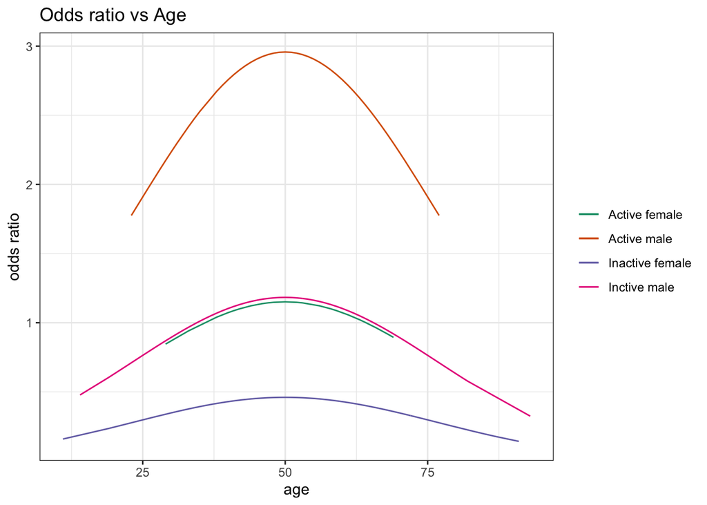

```r
# We add the odds_ratio into the dataset.
dataset2 <- dataset2 %>% mutate(odds_ratio=0.08*(2.57^male)*(2.50^activity)*exp((0.07*age)-0.07*(age/10)^2))
# We plot the odds ratio vs age according to the filters
plot1 <- ggplot(data=dataset2, aes(x=age)) +
  geom_line(data = dataset2%>%filter(male==1,activity==1) ,aes(y=odds_ratio, col = "Active male")) +
  geom_line(data = dataset2%>%filter(male==1,activity==0) ,aes(y=odds_ratio, col = "Inctive male")) +
  geom_line(data = dataset2%>%filter(male==0,activity==1) ,aes(y=odds_ratio, col = "Active female")) +
  geom_line(data = dataset2%>%filter(male==0,activity==0) ,aes(y=odds_ratio, col = "Inactive female")) +
  labs(x = "age", y = "odds ratio",
  title = "Odds ratio vs Age") +
  theme_bw() +
  scale_color_brewer(name= NULL, palette = "Dark2")
plot1
```

For active male customers, the odds ratio is always higher than one, indicating that the probability of positve response is always larger than the probability of negative response. For inactive females however, the probability of negative response is always higher, as the odds ratio is always smaller than one. For inactive males and active females, we see that the odds ratio is only smaller than one for younger and older customers.

### Marginal effect of age

Another way to interpret the effect of age on response is to derive the marginal effect. As you can see, the marginal effect of age depends on age and also on the probability of response.

As the probability of response also depends on gender and activity status, the marginal effect of age will be different for the four types of customers we considered before.

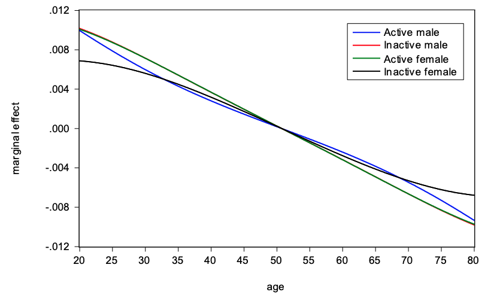

Again, age runs from 20 to 80 years. The marginal effects are modest. For all four types of customers, it equals zero at the age of 50. For lower ages, we see a positive marginal effect, and for higher ages we see a negative marginal effect. Hence, a change in age has a positive effect on response below 50 years, and a negative effect above 50 years.

This result corresponds with the parabolic shape of the odds ratio. The marginal effects are rather similar across the four types of customers. We only see a clear difference for younger and older inactive females.

### In sample forecast analysis

Let us finally perform an in-sample forecast analysis. For all observations in the sample, you can use the logit formula with the estimated value of the parameters to get the predicted probabilities. The quality of fit of the logit model is summarized in the prediction realization table.

As we use the same sampe for prediction $n=m=925$ and cutoff value $c=0.5$

```r
# We add the fitted values to the dataset.
dataset2 <- dataset2 %>% mutate(fitted=predict(logit1, dataset2, type="response"))
# We add a column to clasify the hit type
dataset2 <- dataset2 %>% mutate(hit_type = case_when(
  response==0 & fitted < 0.5 ~ 1,
  response==0 & fitted >= 0.5 ~ 2,
  response==1 & fitted < 0.5 ~ 3,
  response==1 & fitted >= 0.5 ~ 4
)
)
m=925
m_00 <- unlist(dataset2%>%filter(hit_type==1)%>%count()) #hit_type 1
m_01 <- unlist(dataset2%>%filter(hit_type==2)%>%count()) #hit_type 2
m_10 <- unlist(dataset2%>%filter(hit_type==3)%>%count()) #hit_type 3
m_11 <- unlist(dataset2%>%filter(hit_type==4)%>%count()) #hit_type 4
```

|  | y^=0 | y^=1 | Sum |
| --- | --- | --- | --- |
| y=0 | 0.212 | 0.280 | 0.492 |
| y=1 | 0.104 | 0.404 | 0.508 |
| Sum | 0.316 | 0.684 | 1.000 |

Note:  
Cut-off value = 0.5

$$\text{Hit rate : } 0.212+0.404=0.616.$$

As the response rate in the sample is about 50%, a cutoff value of 1/2 is used to transform the predicted probabilities into 0/1 outcomes. As you can see, the **hit rate is about 62%**. It is better than simply doing a random prediction, where you just guest that 51% of the customers will respond and invest.

### Likelihood ratio test

The researcher assumes that a value of 1 corresponds with positive response. What happens if we impose that that positive response is zero and negative response equals 1. The new response variable can be obtained from the old response variable by the following transformation $resp^{new}_i=-resp_i+1$. (All zero observations become one and all one observations become zero).

We estimate the parameters of the same logit specification but use now the new response variable $resp^{new}_i$ as dependent variable.

```r
dataset2 <- dataset2%>%mutate(response_new=-response+1)
logit1_alt <- glm(response_new ~ male + activity + age + I((age/10)^2), data = dataset2, family = "binomial")
summ(logit1_alt)
```

| Observations | 925 |
| --- | --- |
| Dependent variable | response_new |
| Type | Generalized linear model |
| Family | binomial |
| Link | logit |

| 𝛘²(4) | 78.35 |
| --- | --- |
| Pseudo-R² (Cragg-Uhler) | 0.11 |
| Pseudo-R² (McFadden) | 0.06 |
| AIC | 1213.72 |
| BIC | 1237.87 |

|  | Est. | S.E. | z val. | p |
| --- | --- | --- | --- | --- |
| (Intercept) | 2.49 | 0.89 | 2.80 | 0.01 |
| male | -0.95 | 0.16 | -6.03 | 0.00 |
| activity | -0.91 | 0.18 | -4.95 | 0.00 |
| age | -0.07 | 0.04 | -1.96 | 0.05 |
| I((age/10)^2) | 0.07 | 0.03 | 2.01 | 0.04 |

Standard errors: MLE

```r
stargazer(logit1,logit1_alt, type="html", title="Comparisson of logit models")
```

**Comparisson of logit models**

|  | *Dependent variable:* |  |
| --- | --- | --- |
|  | response | response_new |
|  | (1) | (2) |
| male | 0.954*** | -0.954*** |
|  | (0.158) | (0.158) |
| activity | 0.914*** | -0.914*** |
|  | (0.185) | (0.185) |
| age | 0.070** | -0.070** |
|  | (0.036) | (0.036) |
| I((age/10)2) | -0.069** | 0.069** |
|  | (0.034) | (0.034) |
| Constant | -2.488*** | 2.488*** |
|  | (0.890) | (0.890) |
| Observations | 925 | 925 |
| Log Likelihood | -601.862 | -601.862 |
| Akaike Inf. Crit. | 1,213.725 | 1,213.725 |
| *Note:* | p<0.1; p<0.05; p<0.01 |  |

$~$

The parameter estimates are the negative value of the original estimates. Hence, the interpretation of the parameters stays the same, thus it does not matter how we code the binary variable $y=resp_i$.

Suppose you have two logit models. The first model contains all variables, and the second model is the same as the first one, but now has some restrictions (m) on the parameters beta. Estimate the parameters of both models using maximum likelihood. Denote the maximum likelihood value of the models with all variables by $L(b_1)$, and the maximum likely value of the model with restrictions imposed by $L(b_0)$.

$$\begin{split}
\text{Hypothesis }& \\
& H_0 :\text{m restrictions are correct versus } H_1 : H_0 \space false
\end{split}$$
$$\begin{split}
\text{Test statistic }& \\
& LR = -2(L_0 - L_1) \approx \chi^2(2)
\end{split}$$

```r
logit1 <- glm(response ~ male + activity + age + I((age/10)^2), data = dataset2, family = "binomial")
logit1_rest <- glm(response ~ activity + age + I((age/10)^2) - 1, data = dataset2, family = "binomial")
print(paste("The log_likelihood of the unrestricted model is",logLik(logit1)))
```

```
## [1] "The log_likelihood of the unrestricted model is -601.862358094654"
```

```r
print(paste("The log_likelihood of the restricted model is",logLik(logit1_rest)))
```

```
## [1] "The log_likelihood of the restricted model is -624.534741910288"
```

$$\begin{split}
\text{Test statistic }& \\
& LR = -2((-624.53) - (-601.86)) = 45.34
\end{split}$$

```r
stargazer(logit1,logit1_rest, type="html", title="Unrestricted and restricted logit models")
```

**Unrestricted and restricted logit models**

|  | *Dependent variable:* |  |
| --- | --- | --- |
|  | response |  |
|  | (1) | (2) |
| male | 0.954*** |  |
|  | (0.158) |  |
| activity | 0.914*** | 0.979*** |
|  | (0.185) | (0.181) |
| age | 0.070** | 0.0005 |
|  | (0.036) | (0.006) |
| I((age/10)2) | -0.069** | -0.006 |
|  | (0.034) | (0.010) |
| Constant | -2.488*** |  |
|  | (0.890) |  |
| Observations | 925 | 925 |
| Log Likelihood | -601.862 | -624.535 |
| Akaike Inf. Crit. | 1,213.725 | 1,255.069 |
| *Note:* | p<0.1; p<0.05; p<0.01 |  |

$~$

```r
LR <- -2*(logLik(logit1_rest)-logLik(logit1))
# The chi squared distribution at 95% with 2 df
if(LR>qchisq(0.95,2)){
  print("We reject the Null Hypothesis")
} else{
  print("We accept the Null Hypothesis")
}
```

```
## [1] "We reject the Null Hypothesis"
```

### Conclusion

To conclude, the logit model provides useful insight in effect of age gender and activity status on the probability to invest. The financial firm can use this information, together with response predictions for new customers for better target selection of customers in the future.

Take a look at the other materials available in [my website](https://diego-eco.github.io/)

[^1]: El Colegio de México, diego.lopez@colmex.mx